# Exploration des simulations de stades phénologiques

Gabriel Macé

2025-03-31

## Objectifs :

Nous allons ici faire plusieurs analyses :

Tout d’abord, nous allons utiliser les données vit’adapt pour :

- Comparer la qualité des simulations de nos modèles de phénologie à des données réelles.
- Quantifier l’erreur que peut inclure les données SAFRAN par rapport à une station météo proche de la parcelle.
- Décrire les conséquences sur les différentes périodes d’intérêt.

Puis, nous allons explorer et décrire les simulations de stades phénologiques faites sur nos couples mailles-cépages d’intérêt (données ESCA).

## Présentation des modèles :

Pour simuler la date de débourrement nous utilisons le modèle SUWE : “Smoothed Utah Wang Engel”.

Ce modèle permet de simuler trois stades phénologiques : Le débourrement, la floraison et la veraison.

L’idée de ce modèle est de cumuler les unités de chaleur de chaque jour jusqu’à atteindre un seuil, spécifique à chaque cépage. Le point de départ est ici le 213ème jour de l’année n-1. Pour chaque jour, plus on est proche d’une température optimale (ici 26.1 °C), plus la valeur de l’unité de chaleur est forte (de 0 à 1) :

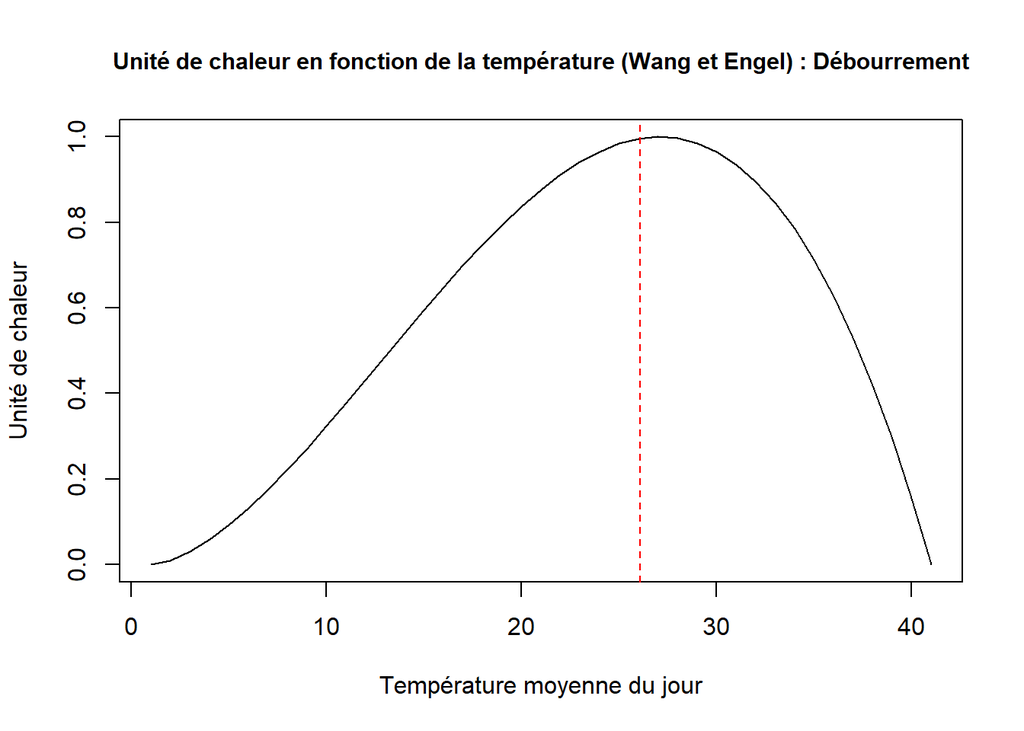

Le jour de débourrement est le jour où le cumul d’unité de chaleur dépasse le seuil du cépage.

Ce modèle est calibré pour les cépages : “cabernet sauvignon”, “chardonnay”, “chasselas”, “grenache”,“merlot”, “monastrell”,“pinot noir”, “riesling”, “sauvignon blanc”, “syrah”,“ugni blanc”, “late ripening”.

Ces simulations de débourrement nous permettent aussi d’obtenir celles pour les cépages : “meunier”, “chenin”, “cabernet franc”, “melon”,“gewurztraminer”, “trousseau”, “savagnin”, “semillon”, “pinot auxerrois”, “gamay”, “poulsard”, “muscat de hambourg”, “cinsault”, “carignan”, “mourvedre”, “muscat petits grains”, “niellucciu”, “vermentinu”, “fer servadou”.

Pour la floraison, nous avons deux solutions :

- Utiliser le modèle SUWE. Cette fois ci, le jour de départ est le jour d’après le débourrement, et la température optimale est de 29.34 °C :

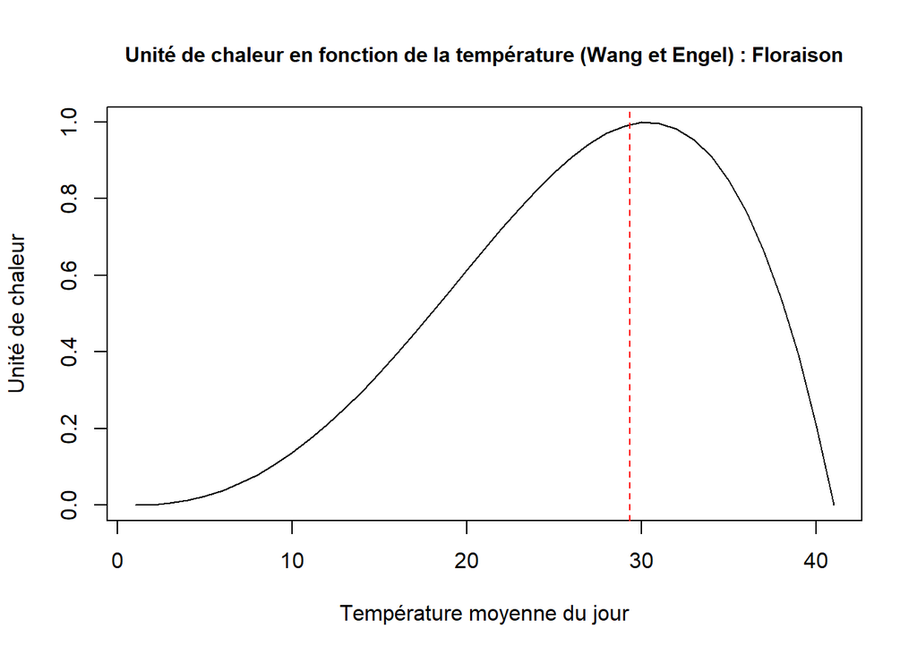

Les cépages disponibles sont les 12 cépages sur lesquels le modèle SUWE est calibré.

- GFV : “Grapevine Flowering Veraison” : Ce modèle permet de simuler deux stades phénologiques : La floraison et la veraison. On ne s’intéressera ici qu’à la floraison. A partir d’une date fixe (le 60 ème jour de l’année / ~1er mars), et de données quotidiennes de températures, le modèle cumul les degrés jusqu’à atteindre un seuil spécifique à chaque cépage. Le jour de dépassement de ce seuil sera le jour de floraison prédit.

Ce modèle est calibré pour tous les cépages suivants : “cabernet franc”,“cabernet sauvignon”, “chardonnay”,“chasselas”, “grenache”, “merlot”,“pinot noir”, “riesling”, “sauvignon blanc”, “syrah”, “ugni blanc”, “meunier”, “aligote”, “chenin”,“gewurztraminer”, “trousseau”, “savagnin”, “semillon”, “gamay”, “poulsard”, “muscat de hambourg”, “cinsault”, “carignan”, “mourvedre”, “muscat petits grains”.

(A voir Melon et Pinot Auxerrois)

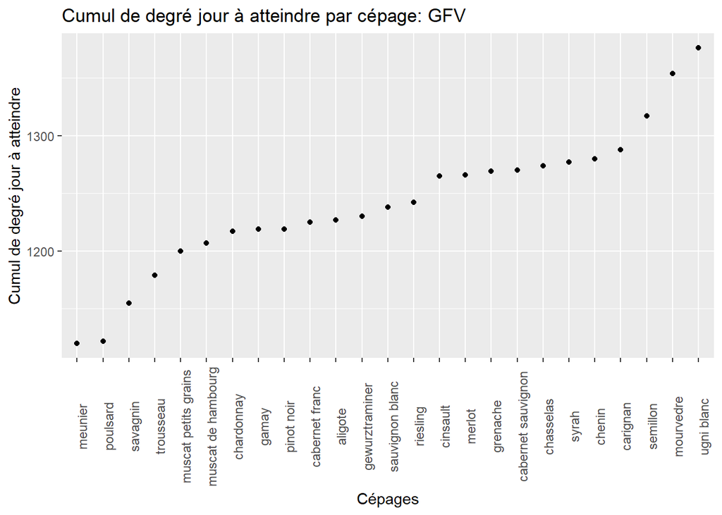

## I - Evaluation des modèles via les observations sur VitAdapt :

Comparaison entre nos simulations et les obsevations réelles (observations vit’adapt).

Nous allons simuler les floraisons de la parcelle grâce aux données de la station météo locale et à nos deux modèles (gfv et SUWE), afin de les comparer aux observations réélles.

### Débourrement :

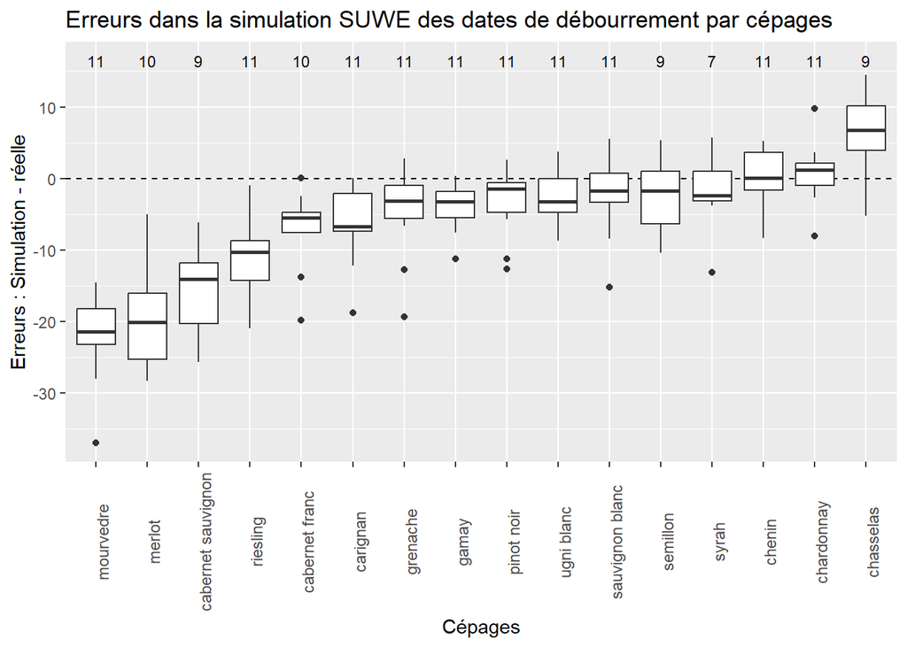

```
## [1] "rmse débourrement :  10.8"
```

```
## [1] "Moyenne de la valeur absolue des erreurs :  7.8"
```

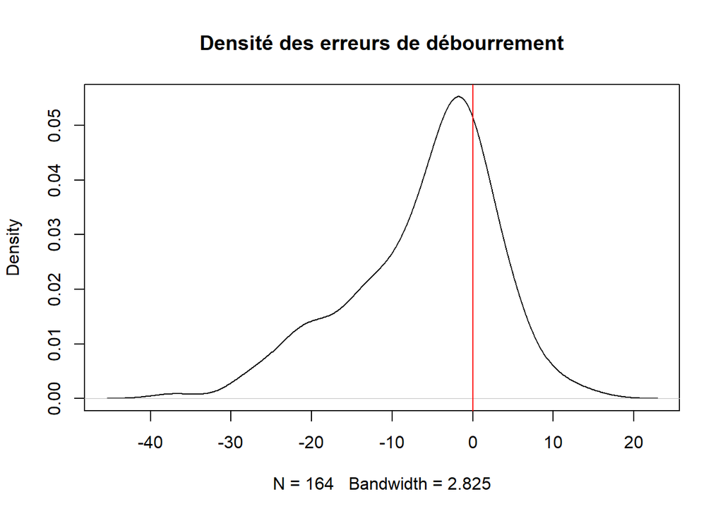

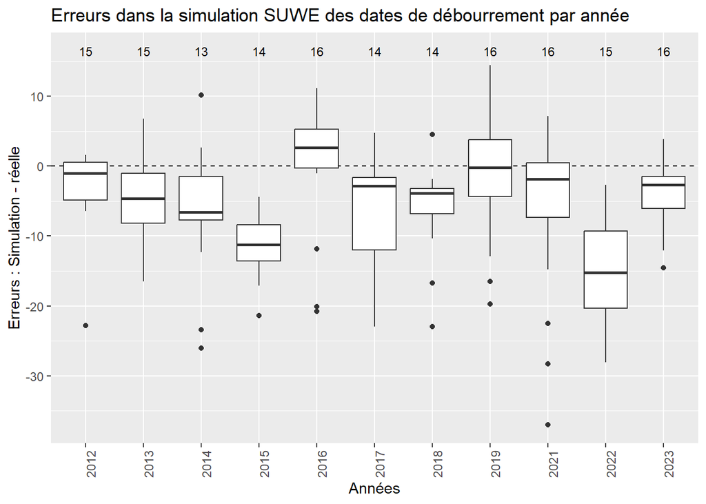

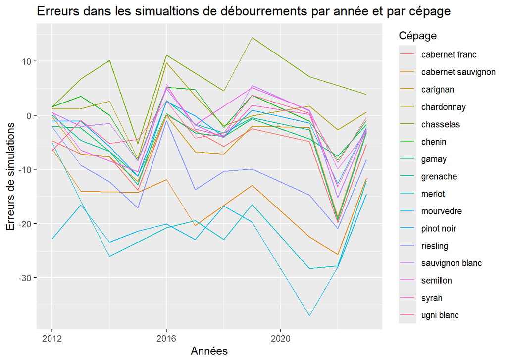

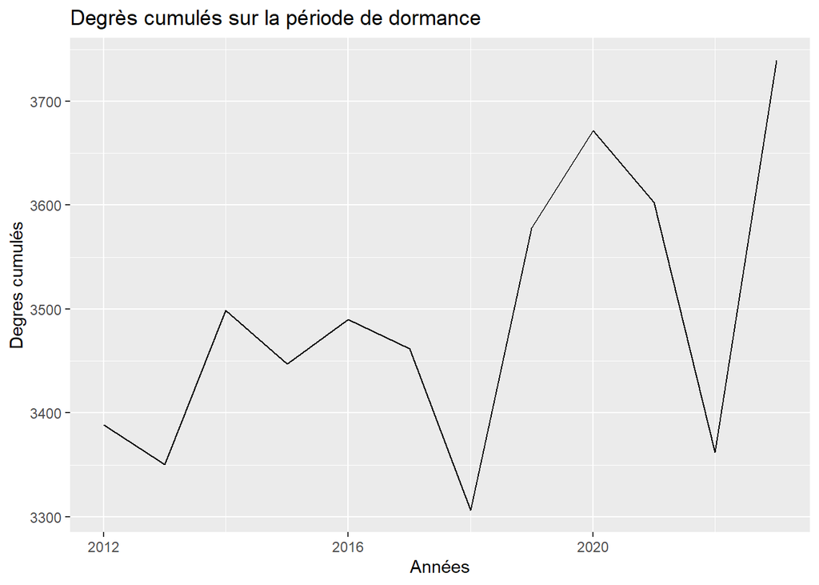

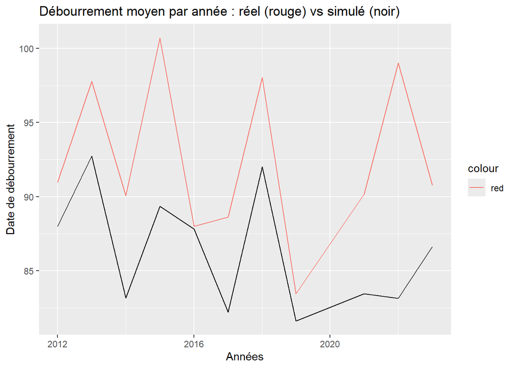

Nous pouvons tout d’abord observer que le modèle SUWE commet beaucoup d’erreurs dans la prédiction des dates de débourrement, elles sont souvent aux alentour de 5 jours trop précoces. Notamment pour les années 2015 et 2022 où les observations réelles de débourrements sont très tardives.

Pour 2015 : le débourrement observé est tardif alors que le cumul de degrès jours est moyen comparé aux autres, tout comme le débourrement prédit.

Pour 2022 : le débourrement observé est tardif alors que le cumul de degrès jours le débourrement prédit sont faibles.

Tous les cépages ont des plus grandes erreurs pour ces 2 années, les erreurs viennent donc du modèle ou du climat, mais pas d’un cépage en particulier.

Enlever ces 2 années améliore évidemment la rmse mais ne permet pas d’obtenir une rmse comparable à celle obtenue pour la floraison, ça n’est pas très utile.

Pour 4 cépages : mourvedre, riesling, cabernet sauvignon, et merlot, la prédiction de débourrement est régulièrement 10 jours trop tôt. Parmis ces 4, il n’y a que le mourvèdre qui n’est pas directement inclus dans le modèle SUWE. Les erreurs ne sont donc pas dûes aux cépages dont le débourrement est dépendant d’un autre cépage.

Aussi, il faut noté que les observations de débourrement (réelles) varient beaucoup selon l’année pour un même cépage. Par exemple, pour le cabernet sauvignon on peut passer du 88eme jours de l’année en 2019, au 105eme en 2022, ce qui représente quand même un écart de 17 jours pour le même cépage.

Hypothèses formulées avec Chloé Delmas :

-> La calibration des paramètres du modèle est faite sur des données où chaque cépage est dans les régions où on le retrouve habituellement. Il y aurait une forme de sur-apprentissage : le modèle fonctionne très bien lorsque que le couple cépage / région est habituel, mais moins lorsque que ce n’est pas le cas, comme avec vitadapt. La plasticité des cépages selon la région n’est pas assez prise en compte.

Aussi les années 2015 / 2022 peuvent être atypiques.

Nous allons par la suite essayé de vérifier ces hypothèses en comparant les simulations de débourrement que nous venons de faire à celle que nous allons faire pour chaque parcelle de producteur (cf : “erreurs_debourrement.Rmd”).

### Floraison :

#### Modèle GFV :

Un individu = un cépage / an.

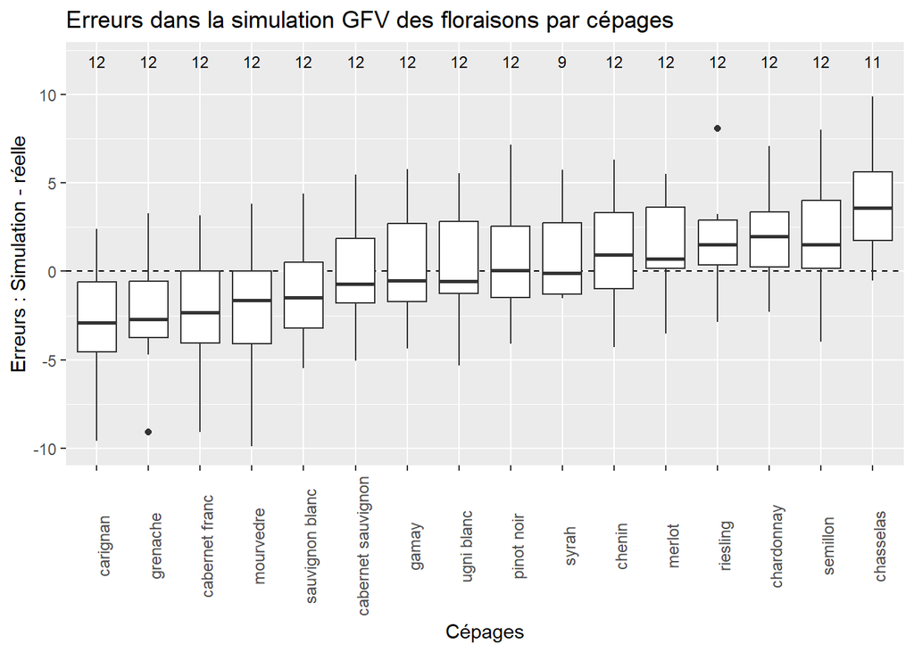

```
## [1] "rmse GFV :  3.48"
```

```
## [1] "Moyenne de la valeur absolue des erreurs :  2.75"
```

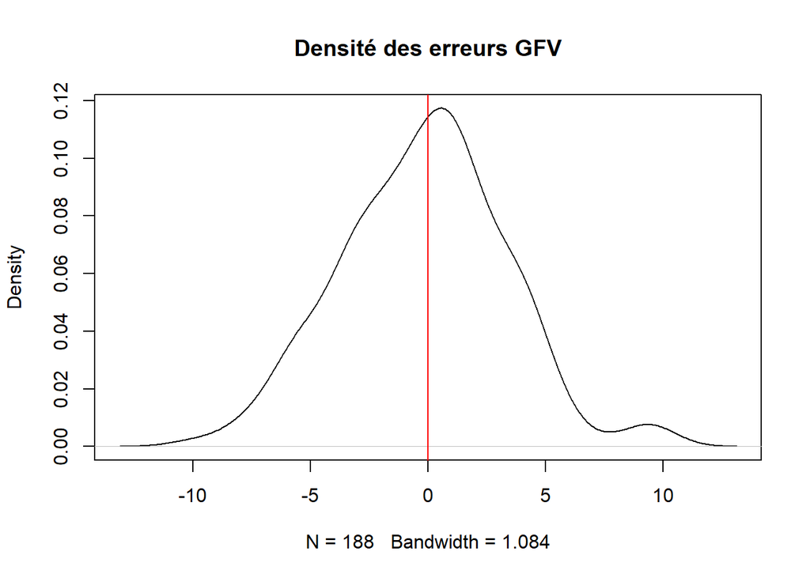

```
## [1] "RMSE par cépages (GFV) :"
```

```
## [1] "cabernet franc : 3.84"
## [1] "cabernet sauvignon : 2.76"
## [1] "carignan : 4.18"
## [1] "chardonnay : 3.44"
## [1] "chasselas : 4.75"
## [1] "chenin : 3.11"
## [1] "gamay : 2.92"
## [1] "grenache : 3.82"
## [1] "merlot : 2.98"
## [1] "mourvedre : 4.33"
## [1] "pinot noir : 3.23"
## [1] "riesling : 3.21"
## [1] "sauvignon blanc : 3"
## [1] "semillon : 3.59"
## [1] "ugni blanc : 3.08"
## [1] "syrah : 2.54"
```

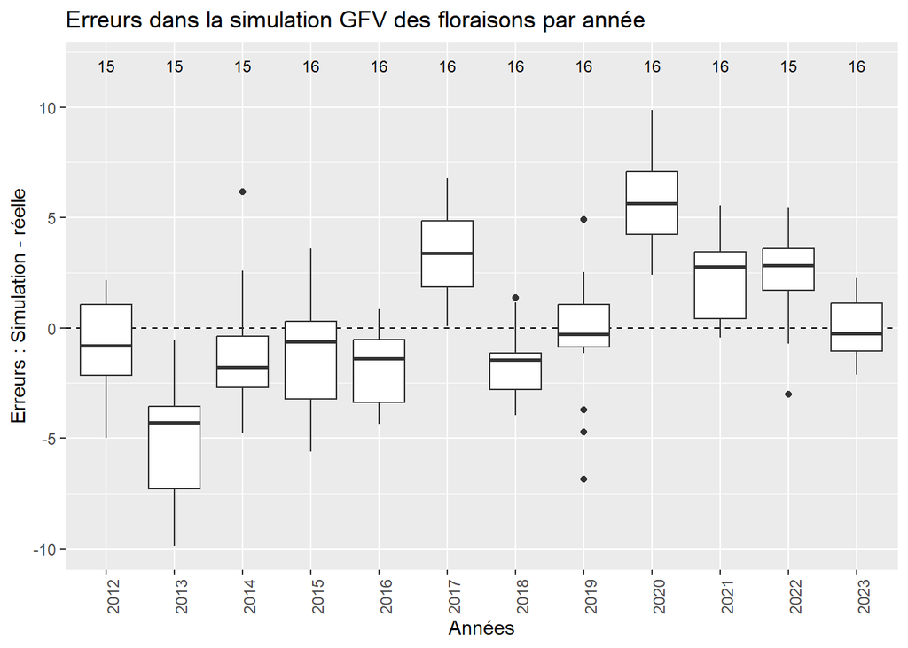

Le modèle gfv commet des erreurs (rmse 3.48), majoritairement inférieures à 5 jours, mais qui peuvent aller jusqu’à 10 jours. Ces erreurs varient selon le cépage et l’année, et semble être normales et centrées en 0.

#### Modèle SUWE :

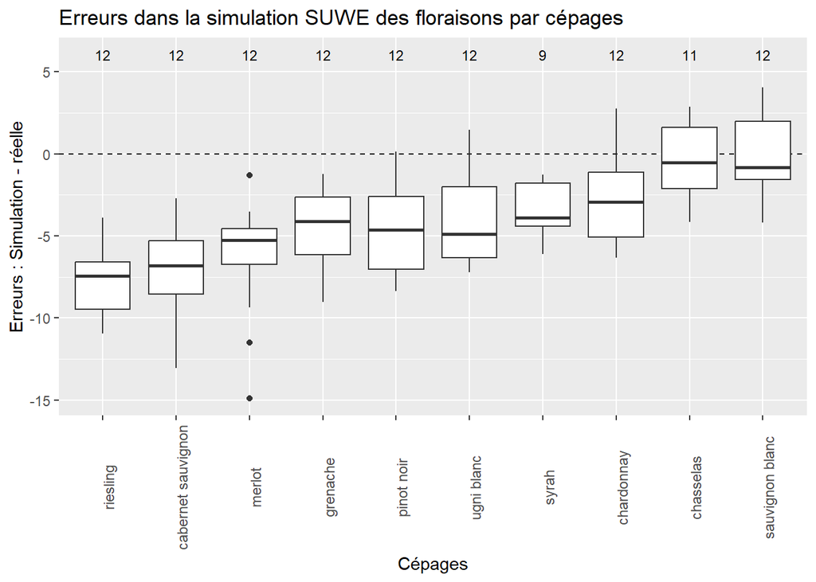

```
## [1] "rmse SUWE :  5.52"
```

```
## [1] "Moyenne de la valeur absolue des erreurs :  4.6"
```

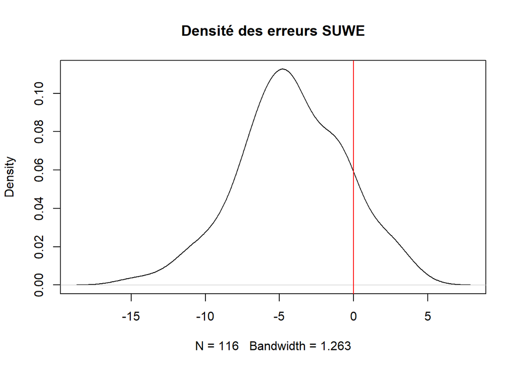

```
## [1] "RMSE par cépages (SUWE) :"
```

```
## [1] "cabernet sauvignon : 7.77"
## [1] "chardonnay : 3.94"
## [1] "chasselas : 2.35"
## [1] "grenache : 5.08"
## [1] "merlot : 7.33"
## [1] "pinot noir : 5.3"
## [1] "riesling : 8.08"
## [1] "sauvignon blanc : 2.57"
## [1] "ugni blanc : 4.8"
## [1] "syrah : 3.87"
```

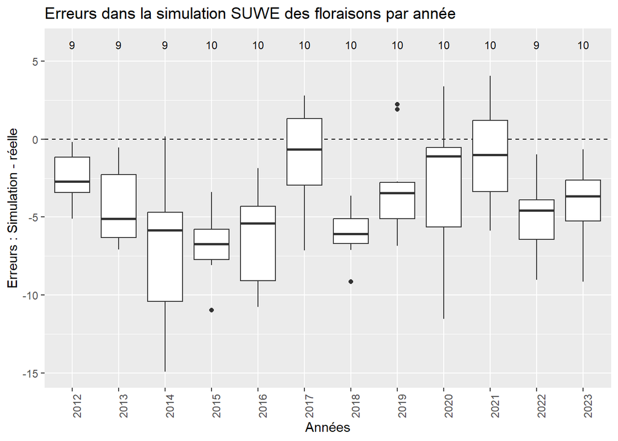

Le modèle SUWE commet des erreurs (rmse 5.52) plus importantes que le modèle gfv. Cette différence semble surtout du à un biais systématique de - 5 jours (trop tôt) comme nous pouvons le voir via la densité des erreurs, car en terme de variabilité des erreurs, les deux modèles sont comparables.

#### Comparaisons des deux modèles de floraisons :

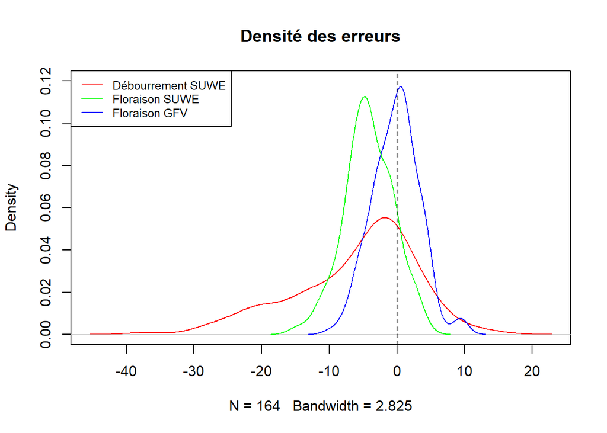

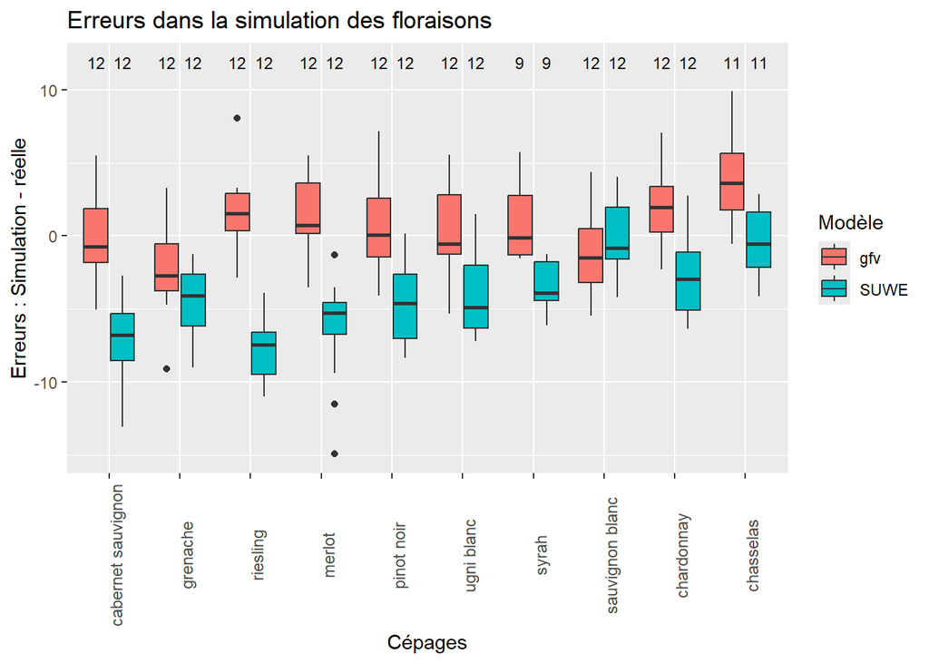

Nous pouvons constater que les deux modèles présentent des erreurs, qui varient selon le cépage et l’année.

La rmse pour le modèle gfv est de 3.48, et elle est 5.52 de pour le modèle SUWE. Aussi, les erreurs dues au modèle gfv semblent normalement distribuées et centrées en 0, alors que le modèle SUWE semble présenter un vrai biais et prévoit des floraisons trop précoce avec des erreurs centrées en - 5 (5 jours trop tôt).

#### Floraison SUWE avec débourrement observé :

Pour savoir si le biais de 5 jours du modèle SUWE vient du débourrement, nous allons refaire les simulations de floraison via ce modèle mais cette fois en partant des débourrements observés sur la parcelle, donc sans les simulés :

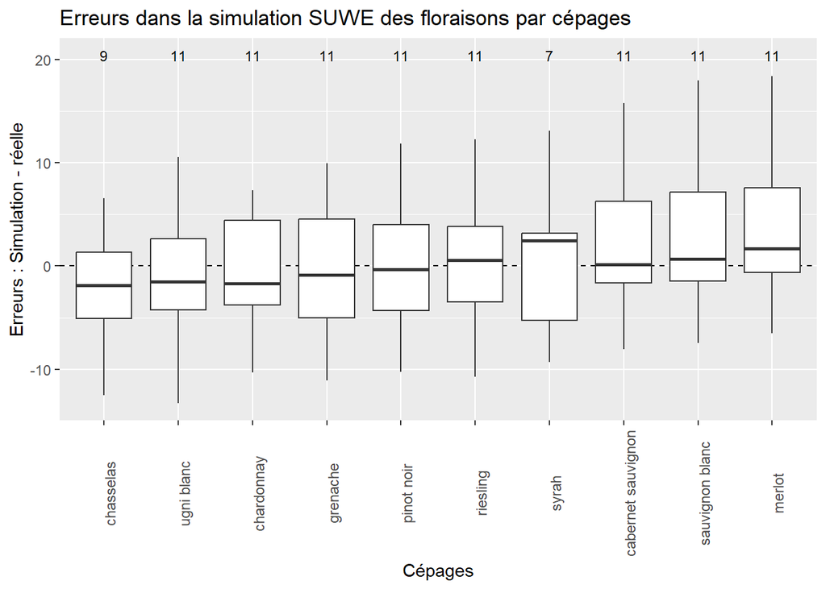

```
## [1] "rmse SUWE :  6.68"
```

```
## [1] "Moyenne de la valeur absolue des erreurs :  5.36"
```

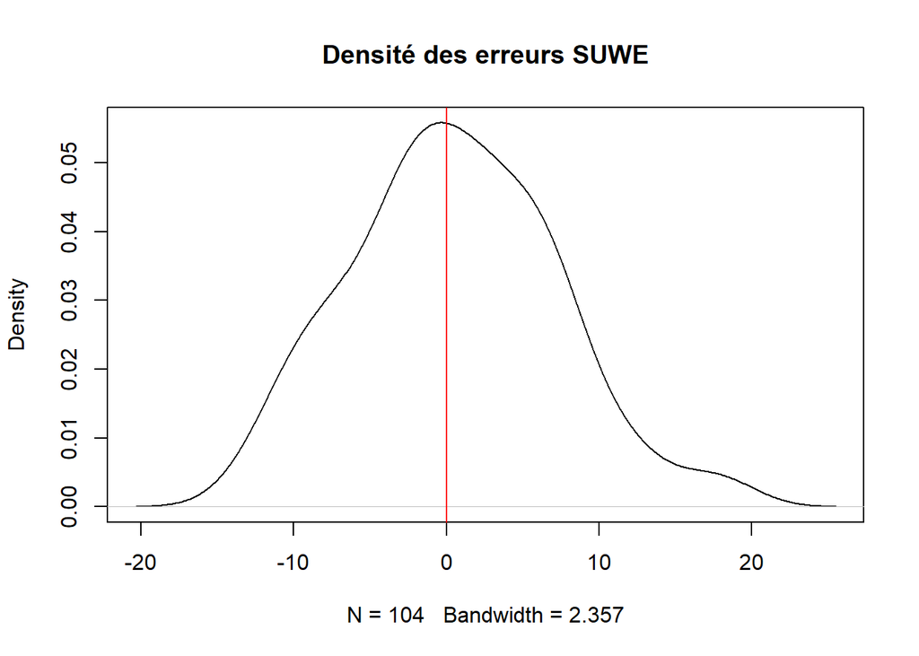

```
## [1] "RMSE par cépages (SUWE) :"
```

```
## [1] "cabernet sauvignon : 6.74"
## [1] "chardonnay : 5.86"
## [1] "chasselas : 6.16"
## [1] "grenache : 6.09"
## [1] "merlot : 7.71"
## [1] "pinot noir : 6.55"
## [1] "riesling : 6.36"
## [1] "sauvignon blanc : 7.5"
## [1] "ugni blanc : 6.6"
## [1] "syrah : 7.01"
```

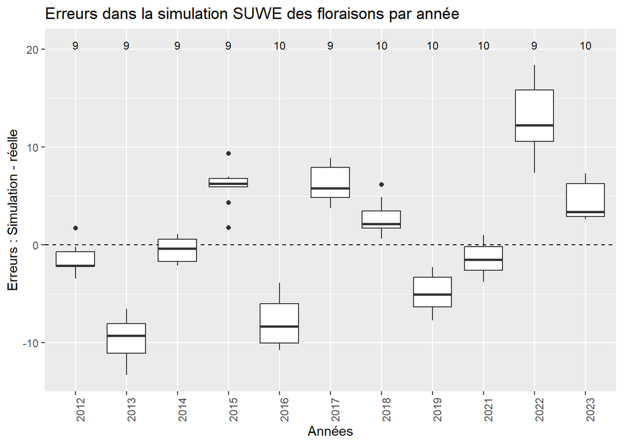

Avec un débourrement observé la simulation SUWE de la floraison est centrée en 0, mais il y a une grande variabilité selon l’année, venant directement des dates de débourrement observées qui sont déjà très variables : Le biais de 4 à 5 jours trop tôt vient bien du débourrement, mais cela n’explique pas l’ensemble des erreurs.

## II - Sensibilité des modèles à des données climatiques maillées (SAFRAN) :

Nous allons maintenant essayer de quantifier l’erreur que peuvent amener les données climatiques SAFRAN dans nos modèles, par rapport à des données climatiques locales.

Nous allons faire des simulations pour la même parcelle mais avec les données SAFRAN.

### Débourrement :

```
## [1] "rmse (observations vs simulations SAFRAN) débourrement :  10.12"
```

```
## [1] "rmse (simulations stations vs simulations SAFRAN) :  1.63"
```

```
## [1] "Moyenne des écarts (Station - SAFRAN) :  -1.24"
```

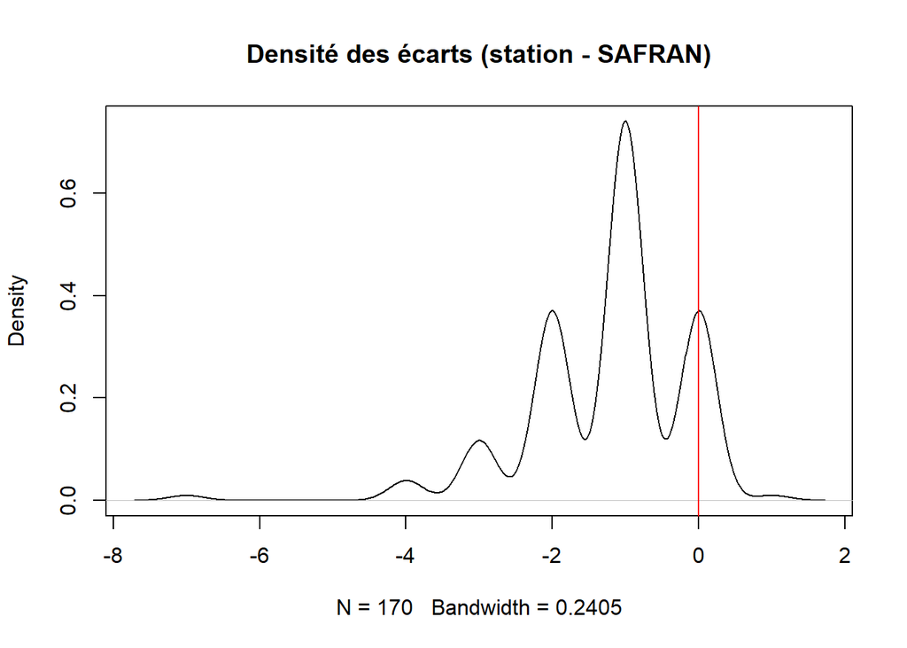

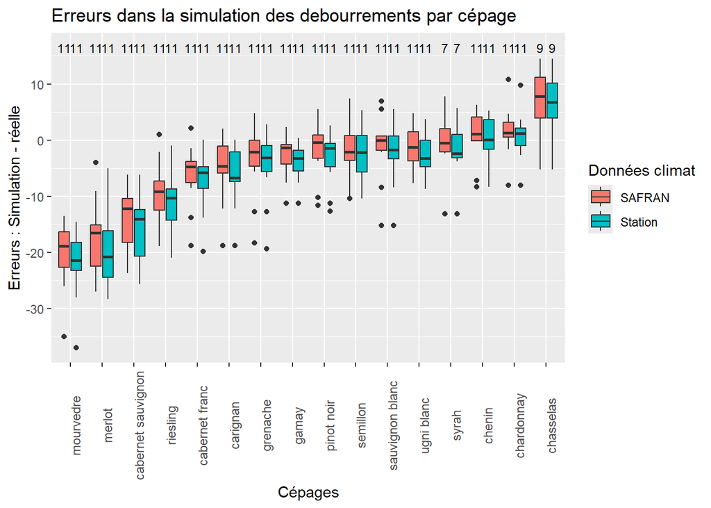

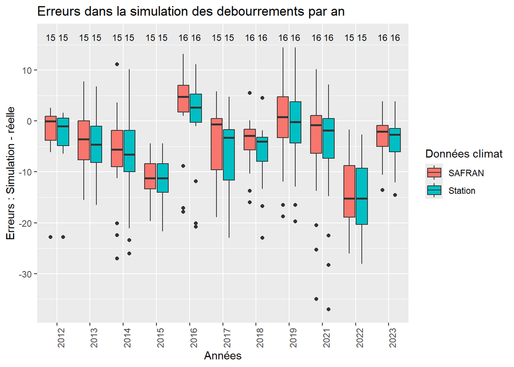

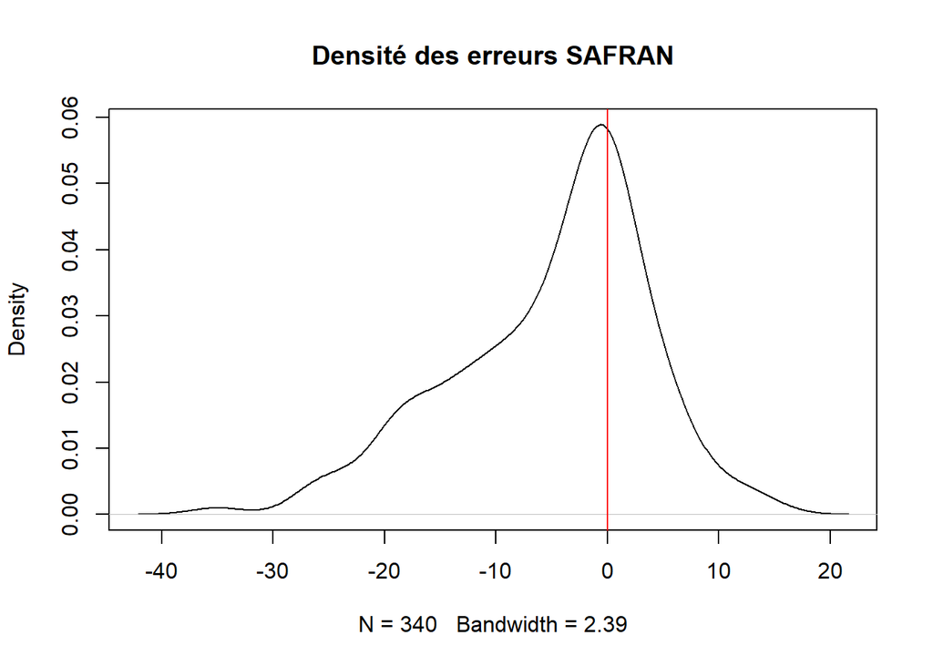

### Floraison :

#### Modèle GFV :

```
## [1] "rmse (observations vs simulations SAFRAN) GFV :  3.7"
```

```
## [1] "rmse (simulations stations vs simulations SAFRAN) GFV :  1.29"
```

```
## [1] "Moyenne des écarts (Station - SAFRAN) :  -1.04"
```

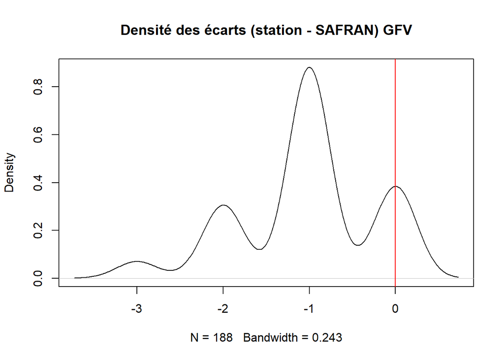

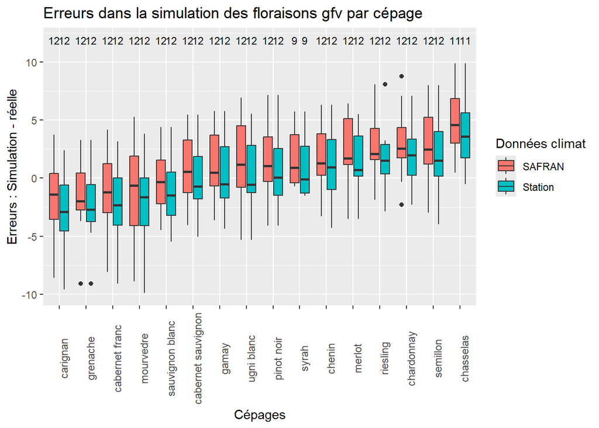

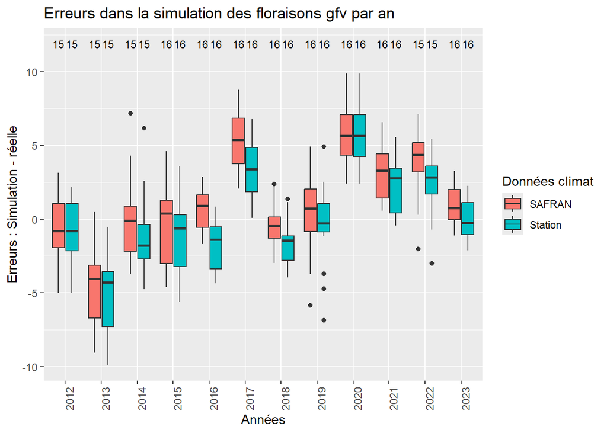

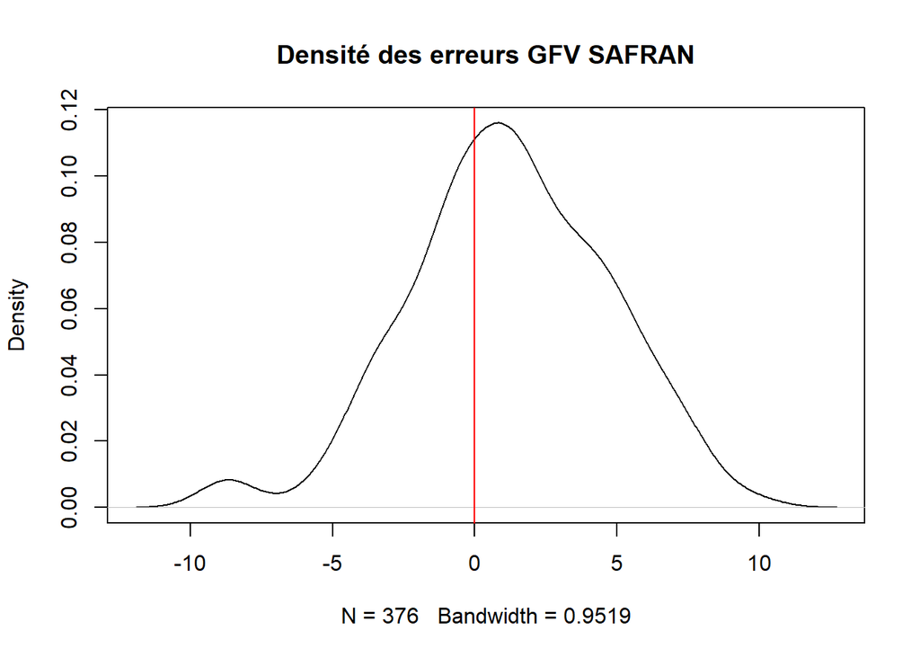

#### Modèle SUWE :

```
## [1] "rmse (observations vs simulations SAFRAN) SUWE :  4.35"
```

```
## [1] "rmse (simulations stations vs simulations SAFRAN) SUWE :  1.77"
```

```
## [1] "Moyenne des écarts (Station - SAFRAN) :  -1.38"
```

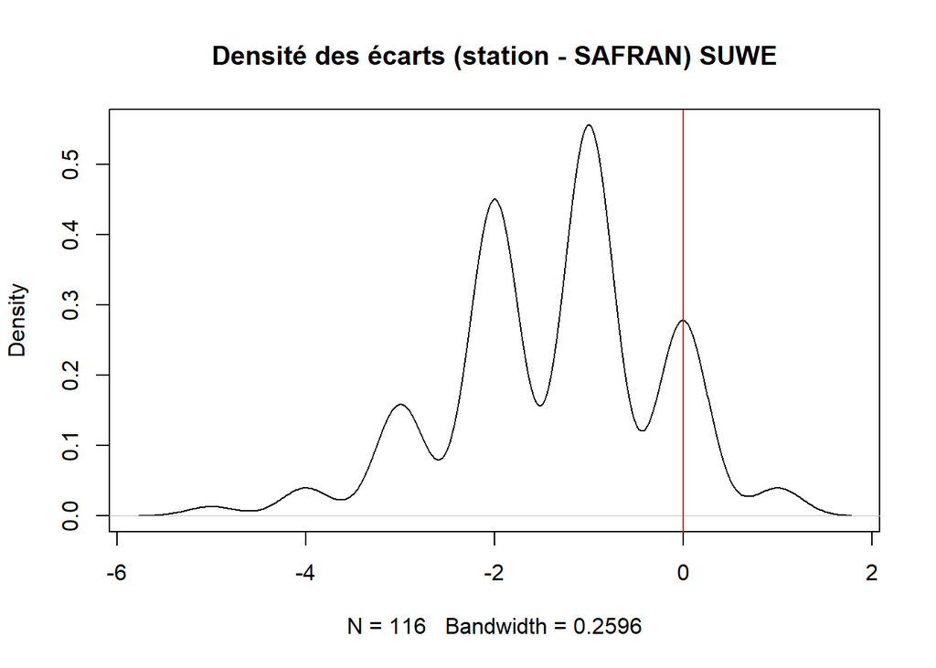

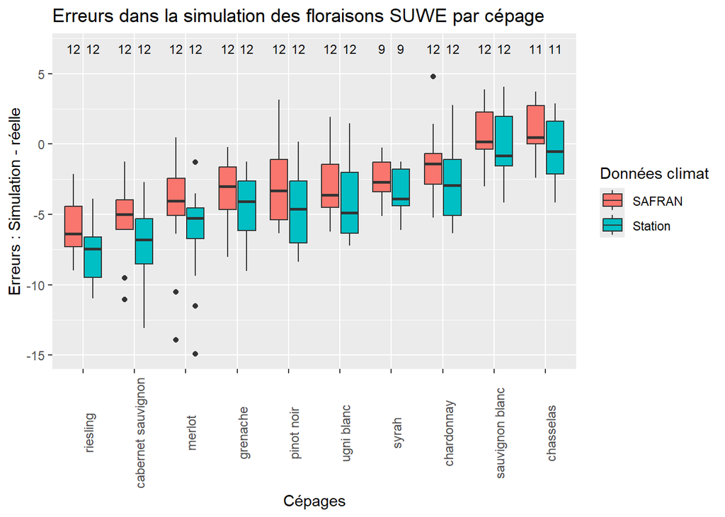

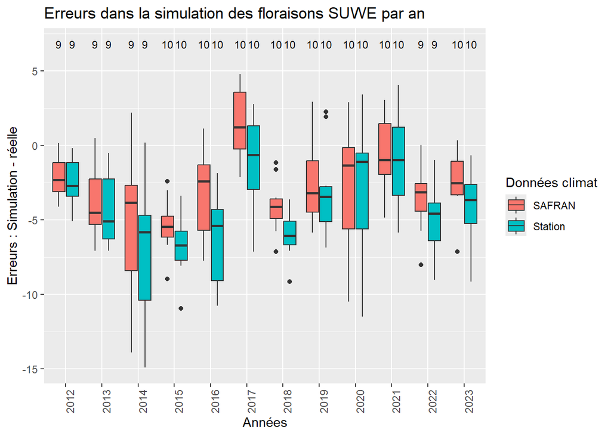

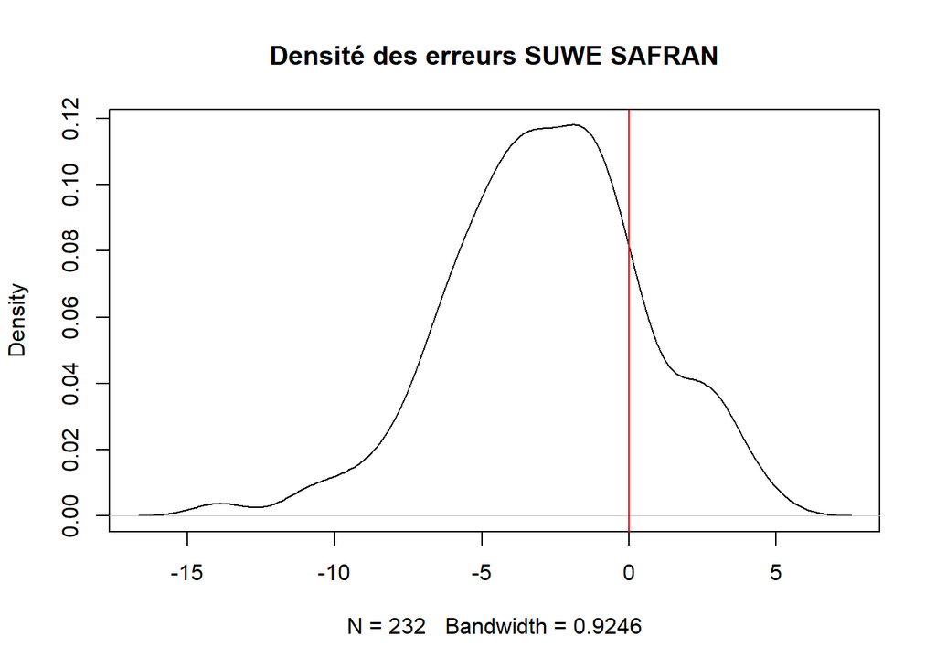

Peu importe le stade phénologique simulé et le modèle utilisé, les différences ne sont pas énormes, mais il y a une variabilité selon le cépage, et l’année. Les données climatiques issues de la station locale semblent engendrer des floraisons et des débourrements 1 à 2 jours plus précoces que via les données SAFRAN (plus de degrés jours via la station locale).

Ducoup, les données SAFRAN augmente la RMSE (comparée à celle avec les données locales) pour le modèle GFV (3.7), mais la diminue pour SUWE (4.35) car les deux biais (SUWE et SAFRAN) ne sont pas dans le même sens.

On peut faire les mêmes observations pour le débourrement.